# About

> The Peak District STEAM Dashboard is an interactive one-stop shop for tourism volume and value data in the Peak District National Park.

> Strategy and Performance Team

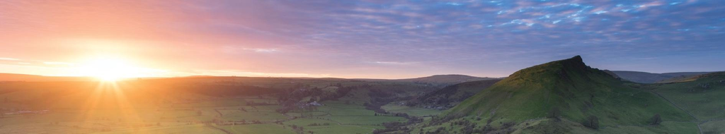

# Visitor Monitoring

The state of tourism in the Peak District National Park is influenced by the inherent characteristics of the place. Its treasured open landscapes, within striking distance a number of major cities, make it one of England’s most accessible outdoor destinations. The Peak District National Park is surrounded by major urban conurbations with 16.1 million people living within 40 miles or approximately an hour’s drive of the national park boundary.

This influences the type of visitor to the national park, as well as the associated economic, environmental and social impacts. Various surveys have tried to assess the volume of visits to the Peak District National Park. Estimates range from 11 million visitor days to 23 million visitor days each year. About half of visitors (48% Visitor Survey 2005) to the Peak District make only short visits (less than three hours) but they are often frequent repeat visitors. They are classed as ‘leisure visitors’ rather than tourists (who have to stay more than 3 hours).

Quantifying both types of visitor is incredibly difficult without regular and comprehensive visitor surveying, which would be prohibitively expensive.We therefore use STEAM to assess the economic volume and value of tourist activity accross the Peak District for thise visitors who stay longer than three hours and are more likely to leave an economic footprint.

# STEAM Model

STEAM is a tourism economic impact modelling process which approaches the measurement of tourism from the bottom up, through its use of local supply side data and tourism performance and visitor survey data collection. The STEAM process is designed to engage the client and maximise the benefit of local tourism expertise. The STEAM process is essentially a structured framework with the capacity to accept a wide range of tourism input data. All of these inputs can be adjusted monthly, to reflect seasonal variations in supply and demand or to reflect specific reporting requirements.

STEAM quantifies the local economic impact of tourism, from both staying and day visitors, through analysis and use of a variety of inputs including visitor attraction numbers, tourist accommodation bedstock, events attendance, occupancy levels, accommodation tariffs, macro-economic factors, visitor expenditure levels, transport use levels and tourism-specific economic multipliers. Throughout the year, we continuously review STEAM input data and consider, for each reporting area, the robustness of the inputs. This review process ensures that any identified weaknesses in data flow can be addressed.

STEAM uses the above input data to generate a series of impact analyses, relating to four key visitor types:

1. Staying in Serviced Accommodation
2. Staying in Non-Serviced Accommodation
3. Staying with Friends and Relatives (SFR)
4. Tourist Day Visitors

Within the model, the above visitor types are broken down further into sub-categories of accommodation use and, where required, sub-types of day or SFR visitor. This allows the model to ensure that its outputs reflect the differences in supply and consumption of tourism services between different types of tourism business. It carries a further benefit in that the outputs relating to specific sub-categories of visitor can be presented in isolation, excluded or combined to reflect specific reporting needs..

More information can be found at http://www.globaltourismsolutions.co.uk/steam-model

STEAM has been calculated to the National Park Boundary and the influence area which is defined as the extent of the landscape character area. See map below.

### Map of the STEAM Influence Area Boundary

[interactive chart not shown]

# Key Measures

### Visitor Days

[interactive chart not shown]

### Visitor Numbers

[interactive chart not shown]

### Economic Impact

[interactive chart not shown]

### Employment

[interactive chart not shown]

# Volume

### Visitor Numbers

|  | JAN | FEB | MAR | APR | MAY | JUN | JUL | AUG | SEP | OCT | NOV | DEC | TOTAL | Annual Change |
| --- | --- | --- | --- | --- | --- | --- | --- | --- | --- | --- | --- | --- | --- | --- |
| % Change 2009 to 2015 | -6.90% | 9.20% | 8.70% | -6.50% | -13.80% | 2.90% | 11.50% | -10.80% | 6.10% | 3.60% | 29.40% | 13.10% | 0.90% | # |
| % Change 2014 to 2015 | 16.70% | -3.10% | 16.70% | 3.20% | 0.40% | 1.50% | 2.00% | -5.00% | -3.10% | 9.60% | 8.50% | 0.60% | 2.20% | # |
| Average Annual Change | -1.20% | 1.50% | 1.50% | -1.10% | -2.30% | 0.50% | 1.90% | -1.80% | 1.00% | 0.60% | 4.90% | 2.20% | 0.20% | # |
| 2009 (Millions) | 0.35 | 0.4 | 0.46 | 1.02 | 1.05 | 0.8 | 0.96 | 1.19 | 0.94 | 0.7 | 0.37 | 0.33 | 8.55 | # |
| 2010 (Millions) | 0.24 | 0.36 | 0.46 | 0.98 | 0.97 | 0.88 | 0.97 | 1.1 | 1.03 | 0.67 | 0.34 | 0.27 | 8.26 | -3% |
| 2011 (Millions) | 0.28 | 0.38 | 0.47 | 1.03 | 0.93 | 0.87 | 1.08 | 1.17 | 1.04 | 0.71 | 0.41 | 0.32 | 8.69 | 5% |
| 2012 (Millions) | 0.29 | 0.37 | 0.49 | 0.88 | 0.91 | 0.88 | 1.03 | 1.15 | 1.01 | 0.64 | 0.42 | 0.33 | 8.41 | -3% |
| 2013 (Millions) | 0.25 | 0.38 | 0.41 | 0.88 | 0.94 | 0.83 | 1.03 | 1.18 | 0.96 | 0.62 | 0.43 | 0.37 | 8.29 | -1% |
| 2014 (Millions) | 0.28 | 0.45 | 0.43 | 0.92 | 0.9 | 0.82 | 1.05 | 1.11 | 1.03 | 0.66 | 0.44 | 0.37 | 8.45 | 2% |
| 2015 (Millions) | 0.32 | 0.43 | 0.5 | 0.95 | 0.9 | 0.83 | 1.07 | 1.06 | 0.99 | 0.72 | 0.47 | 0.37 | 8.63 | 2% |

### Visitor Days

|  | JAN | FEB | MAR | APR | MAY | JUN | JUL | AUG | SEP | OCT | NOV | DEC | TOTAL | Annual Change |
| --- | --- | --- | --- | --- | --- | --- | --- | --- | --- | --- | --- | --- | --- | --- |
| % Change 2009 to 2015 | -7.20% | 5.70% | 14.50% | -3.70% | -7.90% | 8.90% | 9.90% | -5.30% | 7.10% | 5.10% | 24.00% | 8.10% | 3.20% | # |
| % Change 2014 to 2015 | 12.30% | -2.50% | 10.20% | 2.20% | 0.70% | 2.20% | 1.40% | -3.10% | -3.40% | 6.80% | 4.20% | -0.20% | 1.40% | # |
| Average Annual Change | -1.20% | 0.90% | 2.40% | -0.60% | -1.30% | 1.50% | 1.70% | -0.90% | 1.20% | 0.90% | 4.00% | 1.40% | 0.50% | # |
| 2009 (Millions) | 0.48 | 0.54 | 0.62 | 1.27 | 1.46 | 1.17 | 1.39 | 1.7 | 1.32 | 0.94 | 0.51 | 0.47 | 11.87 | # |
| 2010 (Millions) | 0.33 | 0.5 | 0.62 | 1.24 | 1.39 | 1.34 | 1.41 | 1.64 | 1.48 | 0.91 | 0.48 | 0.4 | 11.73 | -1.10% |
| 2011 (Millions) | 0.39 | 0.52 | 0.65 | 1.33 | 1.37 | 1.33 | 1.52 | 1.68 | 1.47 | 0.96 | 0.57 | 0.45 | 12.22 | 4.20% |
| 2012 (Millions) | 0.41 | 0.51 | 0.68 | 1.16 | 1.32 | 1.32 | 1.44 | 1.65 | 1.43 | 0.9 | 0.58 | 0.46 | 11.87 | -2.90% |
| 2013 (Millions) | 0.37 | 0.52 | 0.62 | 1.15 | 1.36 | 1.26 | 1.46 | 1.7 | 1.36 | 0.86 | 0.59 | 0.51 | 11.75 | -1.00% |
| 2014 (Millions) | 0.4 | 0.59 | 0.64 | 1.2 | 1.34 | 1.25 | 1.5 | 1.66 | 1.46 | 0.93 | 0.61 | 0.51 | 12.07 | 2.80% |
| 2015 (Millions) | 0.45 | 0.57 | 0.71 | 1.23 | 1.35 | 1.27 | 1.52 | 1.61 | 1.41 | 0.99 | 0.64 | 0.5 | 12.24 | 1.40% |

# Value

### Value £ Million

|  | JAN | FEB | MAR | APR | MAY | JUN | JUL | AUG | SEP | OCT | NOV | DEC | TOTAL | Annual Change |
| --- | --- | --- | --- | --- | --- | --- | --- | --- | --- | --- | --- | --- | --- | --- |
| % Change 2009 to 2015 | 12.10% | 27.00% | 40.60% | 17.10% | 13.90% | 34.00% | 33.10% | 17.10% | 30.80% | 27.40% | 48.20% | 30.60% | 26.00% | # |
| % Change 2014 to 2015 | 13.60% | -0.40% | 11.50% | 3.60% | 2.60% | 4.30% | 3.00% | -0.40% | -1.50% | 8.30% | 5.40% | 1.40% | 3.20% | # |
| Average Annual Change | 2.00% | 4.50% | 6.80% | 2.90% | 2.30% | 5.70% | 5.50% | 2.90% | 5.10% | 4.60% | 8.00% | 5.10% | 4.30% | # |
| 2009 Millions | 15 | 16.9 | 19.4 | 39.4 | 46 | 37.2 | 46.3 | 56.1 | 41.5 | 29.7 | 16.4 | 14.9 | 378.8 | # |
| 2010 Millions | 10.9 | 16.4 | 20.4 | 40 | 45.5 | 44.2 | 49 | 56.9 | 48.2 | 30 | 15.7 | 13.2 | 390.4 | 3.00% |
| 2011 Millions | 13.5 | 17.6 | 22.3 | 45 | 47.5 | 46.1 | 54.9 | 60.8 | 50.1 | 33.1 | 19.4 | 15.5 | 425.9 | 9.10% |
| 2012 Millions | 14.4 | 18 | 24.2 | 41.3 | 47.7 | 47.9 | 54.6 | 62.3 | 51 | 32.4 | 20.6 | 16.5 | 431.1 | 1.20% |
| 2013 Millions | 13.6 | 18.9 | 23.1 | 41.6 | 50.3 | 47.2 | 56.7 | 66 | 49.9 | 31.8 | 21.8 | 18.7 | 439.6 | 2.00% |
| 2014 Millions | 14.8 | 21.6 | 24.5 | 44.5 | 51 | 47.7 | 59.9 | 66 | 55.1 | 34.9 | 23 | 19.2 | 462.3 | 5.20% |
| 2015 Millions | 16.9 | 21.5 | 27.3 | 46.1 | 52.4 | 49.8 | 61.7 | 65.7 | 54.2 | 37.8 | 24.2 | 19.5 | 477.2 | 3.20% |

# Employment

# Accommodation